# Effective digital notetaking with Obsidian

Scientific workflows: Tools and Tips 🛠️

2023-10-19

## What is this lecture series?

### Scientific workflows: Tools and Tips 🛠️

📅 Every 3rd Thursday 🕓 4-5 p.m. 📍 Webex

- One topic from the world of scientific workflows
- Material provided [online](https://selinazitrone.github.io/tools_and_tips/)
- For topic suggestions send me an email
- If you don’t want to miss a lecture
  - Check out the [lecture website](https://www.bcp.fu-berlin.de/en/graduiertenzentrum/promovierende/veranstaltungen/workshops/lecture-SB/index.html)
  - [Subscribe to the mailing list](https://lists.fu-berlin.de/listinfo/toolsAndTips)

## Motivation

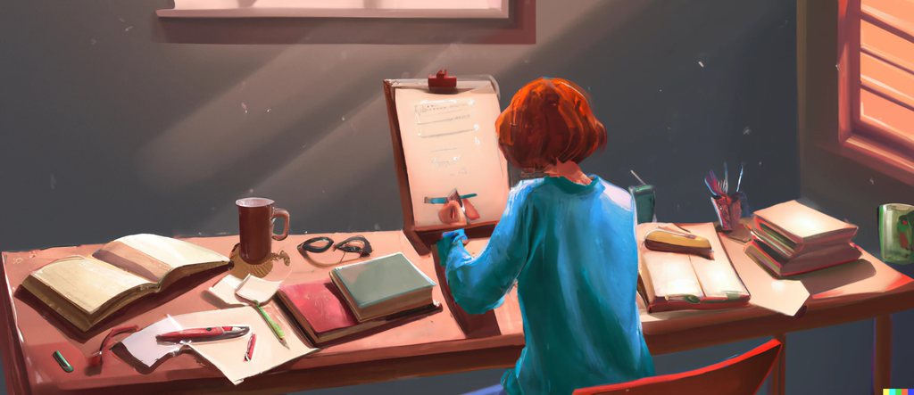

## Obsidian

Obsidian is

- free for personal use
- available for all platforms
- markdown-based
- simple at its core
- highly scalable

[figure not shown]

## Notetaking purposes

- Project management
  - Keep track of project states, tasks, meetings
- Personal management
  - Plan your days and weeks, to-do lists, track your time
- Literature management
  - Connect Obsidian to Zotero
- Idea/Knowledge management
  - Interconnected notes (Zettelkasten)
- . . .

In Obsidian you can connect all these purposes

## Today

- Project management
- Personal management
- Literature management
- Idea/Knowledge management
- Basic overview of Obsidian
- Implement some basic workflows

Find additional material on the lecture website.

# Let’s get started

[figure not shown]

## Summary

Obsidian makes your notes

- 🔎 *searchable* -> digital
- 📆 *sustainable*
  - Can we understand our notes in the future?
  - Will the program still work in the future?
  - No proprietary software format
- 🔗 *connected* -> linking between notes
- 😃 *easy and fun* -> keep motivation to really take notes

## Summary

Benefits

- 🗂️**Stay organized**
- 🧠 **Second Brain**
  - Store knowledge
  - Get stuff out of your first brain
- 💾 **Find information again**, also in 20 years

## Get started

- Have a look at the [demo notebook](https://github.com/selinaZitrone/notebook_demo)
  - Find a video on how to open it [here](https://youtu.be/PyiHAw8bIIc)
- Have a look at the resources linked on the lecture website

## Next lecture

#### Efficient R programming

How to write code efficiently, find bottlenecks in your code and improve the speed of your R programs.

📅 16th November 🕓 4-5 p.m. 📍 Webex

🔔 [Subscribe to the mailing list](https://lists.fu-berlin.de/listinfo/toolsAndTips)

📧 For topic suggestions and/or feedback send me an email

## Thank you for your attention :)

Questions?